# PREGUNTAS

```r
  #3.- Centralidad de cercania
closeness(karate)
```

```
##  [1] 0.01724138 0.01470588 0.01694915 0.01408451 0.01149425 0.01162791
##  [7] 0.01162791 0.01333333 0.01562500 0.01315789 0.01149425 0.01111111
## [13] 0.01123596 0.01562500 0.01123596 0.01123596 0.00862069 0.01136364
## [19] 0.01123596 0.01515152 0.01123596 0.01136364 0.01123596 0.01190476
## [25] 0.01136364 0.01136364 0.01098901 0.01388889 0.01369863 0.01162791
## [31] 0.01388889 0.01639344 0.01562500 0.01666667
```

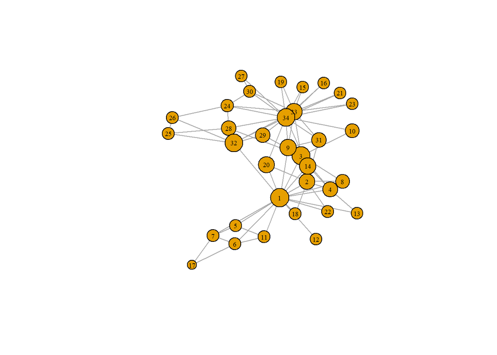

```r
V(karate)$closeness <- closeness(karate)
plot(karate,
     vertex.label.cex = .6,
     vertex.label.color = "black",
     vertex.size = V(karate)$closeness/max(V(karate)$closeness) * 20)
```

```r
  #4.- Centralidad del vector propio.
eigen_centrality(karate)$vector
```

```
##  [1] 0.95213237 0.71233514 0.84955420 0.56561431 0.20347148 0.21288383
##  [7] 0.21288383 0.45789093 0.60906844 0.27499812 0.20347148 0.14156633
## [13] 0.22566382 0.60657439 0.27159396 0.27159396 0.06330461 0.24747879
## [19] 0.27159396 0.39616224 0.27159396 0.24747879 0.27159396 0.40207086
## [25] 0.15280670 0.15857597 0.20242852 0.35749923 0.35107297 0.36147301
## [31] 0.46806481 0.51165649 0.82665886 1.00000000
```

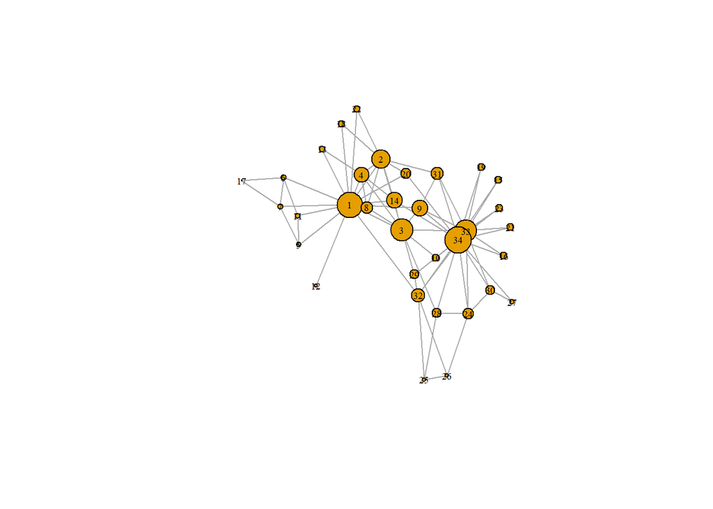

```r
V(karate)$eigenvector <- eigen_centrality(karate)$vector

plot(karate,
     vertex.label.cex = .6,
     vertex.label.color = "black",
     vertex.size = V(karate)$eigenvector/max(V(karate)$eigenvector) * 20)
```

### **AMIGUES**

**A partir de la red de amigues que vimos en clase, en su versión no ponderada, contesta lo siguiente:**

- **Escribe una función que calcule el número de amigos que tiene cualquier persona arbitraria y lo compare con el número de los amigos de estos.**

  ```r
  amigos_comparacion <- function(grafo, nombre){
  #Escribe una función que calcule el número de amigos que tiene cualquier persona
    amigos <- degree(grafo, v=nombre, mode = "out")#que considera amigos
    cat("amigos que considera:", amigos, "\n")
    amigos2 <- degree(grafo, v=nombre, mode = "in")
    cat("lo consideran su amigos:", amigos2, "\n")
     #compare con el número de los amigos de estos
    amigos3 <- neighbors(grafo, v = nombre)
    #cat("amigos de sus amigos:", amigos3, "\n")---NO SALE
    print(amigos3)
    grados_amigos <- degree(grafo, v = amigos3)
    cat("compare con el número de los amigos de estos:", grados_amigos, "\n")
    promedio_amigos<- mean(grados_amigos)
    cat("EL PROMEDIO DE AMIGOS ES:", promedio_amigos, "\n")

  }
  ```

- **Escribe una función que te de la trayectoria más larga entre dos nodos arbitrarios de la red.**

  ```r
  #comillas y mayuscula(from, to)
  lejanos_amigos <- function(grafo, nombre1, nombre2){
    trayectorias <- all_simple_paths(red, from = nombre1, to = nombre2)
    #rayectoria más larga entre dos nodos
    largos1 <- sapply(trayectorias, length)
    lejano1 <- max(largos1) #para que saque cual es la mas larga
    trayectoria_larga <- trayectorias[largos1 == lejano1]
    print(trayectoria_larga)
  }
  ```

- **Encuentra las dos personas más populares.**